# Capítulo IV

### 4.6.5. Máquinas de Vetor de Suporte

As *máquinas de vetores de suporte* (*support vector machines* - SVM) são classificadores baseados em um princípio geométrico ótimo: encontrar o hiperplano de separação que *maximiza a margem* entre classes distintas. Esta abordagem formula o problema de aprendizagem como um problema de *otimização convexa*, garantindo uma solução única e robusta para o vetor normal do hiperplano, $w$, sob condições gerais (Cortes e Vapnik 1995; Vapnik 1998).

**(I) Construção do Problema**

Considere um conjunto de treinamento composto por $n$ observações independentes, representado por pares ordenados $\{(x_i, y_i)\}_{i=1}^n$, onde $x_i \in \mathbb{R}^p$ é o vetor de características da $i$-ésima observação e $y_i \in \{-1, +1\}$ seu rótulo de classe binário. O objetivo da SVM é determinar uma *função de decisão linear* $f: \mathbb{R}^p \to \mathbb{R}$ que separe essas observações em duas regiões distintas de modo a *maximizar a margem* entre as classes. Essa função, em particular, é definida por um *hiperplano* caracterizado por um vetor normal $w \in \mathbb{R}^p$ e um intercepto $b \in \mathbb{R}$:
$$\begin{align}\\
f(x) = w^\top x + b\\\\
\end{align}$$
A regra de classificação atribui a classe $+1$ se $f(x) > 0$ e a classe $-1$ se $f(x) < 0$. Dessa forma, o problema de classificação é reduzido a um problema *geométrico de separação por hiperplanos*. O objetivo, portanto, é selecionar $w$ e $b$ que não apenas classifiquem corretamente os dados de treinamento — isto é, satisfaçam $y_i f(x_i) > 0$ para todo $i$ — mas que também *maximizem a distância mínima* entre os pontos e o hiperplano decisório. Essa distância, denominada *margem geométrica* do ponto $(x_i, y_i)$ em relação ao hiperplano, é definida como:
$$\begin{align}\\
\gamma_i = \frac{y_i (w^\top x_i + b)}{\|w\|}\\\\
\end{align}$$
Portanto, maximizar o valor da menor margem geométrica entre todas as observações, $\min_{i} \gamma_i$, conduz diretamente ao *problema de otimização convexa* que define a SVM.

**(II) Margem Rígida (Dados Linearmente Separáveis)**

Quando as classes são perfeitamente separáveis, impõe-se que todos os pontos satisfaçam $y_i f(x_i) \geqslant 1$, onde a constante $1$ define uma normalização conveniente para a *margem funcional* $y_i f(x_i)$. Isto leva ao problema de *otimização quadrática*:
$$\begin{align}\\
\min_{w, b} \quad & \frac{1}{2} \|w\|^2 \\\\
\text{sujeito a} \quad & y_i (w^\top x_i + b) \geqslant 1, \quad i = 1, \dots, n\\\\
\end{align}$$

**Interpretação Geométrica:** As restrições $y_i f(x_i) \geqslant 1$ implicam que todos os pontos residem fora ou sobre os *hiperplanos marginais* $w^\top x + b = \pm 1$. A distância entre estes dois hiperplanos paralelos — a *largura da margem* — é $\frac{2}{\|w\|}$. Consequentemente, minimizar $\|w\|^2$ é equivalente a maximizar a largura do corredor de separação.

**(III) Margem Suave (Classes Sobrepostas)**

Para dados não separáveis linearmente, introduzem-se *variáveis de folga* $\xi_i \geq 0$ que permitem violações controladas das restrições de margem, e um parâmetro de regularização $C > 0$ que pondera a penalização por essas violações:
$$\begin{align}\\
\min_{w, b, \xi} \quad & \frac{1}{2} \|w\|^2 + C \sum_{i=1}^n \xi_i \\\\
\text{sujeito a} \quad & y_i (w^\top x_i + b) \geqslant 1 - \xi_i, \quad i = 1, \dots, n \\\\
& \xi_i \geqslant 0, \quad i = 1, \dots, n\\\\
\end{align}$$
Aqui, $\xi_i$ quantifica a violação: se $0 < \xi_i \leqslant 1$, o ponto está no lado correto mas dentro da margem; se $\xi_i > 1$, ocorre erro de classificação. Esta formulação é *equivalente à minimização da perda hinge*:
$$\begin{align}\\
\min_{w, b} \; \frac{1}{2} \|w\|^2 + C \sum_{i=1}^n \max\bigl(0, 1 - y_i (w^\top x_i + b)\bigr)\\\\
\end{align}$$
revelando seu caráter de *modelo regularizado* (Hastie, Tibshirani, e Friedman 2009; Alpaydin 2021).

**(IV) Formulação Dual**

Embora o problema primal de otimização apresentado anteriormente seja adequado para explicitar o princípio de maximização da margem, ele não constitui a forma mais conveniente para a sua resolução prática. Em particular, essa formulação exige a otimização direta do vetor $w \in \mathbb{R}^p$, o que pode ser computacionalmente custoso em contextos de alta dimensionalidade, além de não evidenciar a estrutura esparsa da solução — isto é, o fato de que apenas um subconjunto das observações contribui efetivamente para a determinação do hiperplano separador. Essas limitações motivam a reformulação do problema por meio de sua *formulação dual* (Cortes e Vapnik 1995; Vapnik 1998; Hastie, Tibshirani, e Friedman 2009). Para esse fim, associam-se multiplicadores de Lagrange $\alpha_i \geqslant 0$ às restrições de margem e $\mu_i \geqslant 0$ às restrições de não negatividade das variáveis de folga $\xi_i \geqslant 0$, resultando no Lagrangiano:
$$\begin{align}\\
\mathcal{L}(w,b,\xi,\alpha,\mu) = \frac{1}{2}\|w\|^2 + C\sum_i \xi_i - \sum_i \alpha_i\bigl[y_i(w^\top x_i+b)-1+\xi_i\bigr] - \sum_i \mu_i \xi_i\\\\
\end{align}$$

A formulação dual é então obtida pela minimização do Lagrangiano em relação às variáveis originais $(w,b,\xi)$, seguida da análise das condições de otimalidade associadas ao problema com restrições, conhecidas como *condições de Karush–Kuhn–Tucker* (KKT). Tais condições podem ser enunciadas da seguinte forma:

- **(a) Estacionariedade:**
  $$\begin{align}\\
  \nabla_w \mathcal{L} &= w - \sum_i \alpha_i y_i x_i = 0 \\\\
  \frac{\partial \mathcal{L}}{\partial b} &= -\sum_i \alpha_i y_i = 0\\\\
  \frac{\partial \mathcal{L}}{\partial \xi_i} &= C - \alpha_i - \mu_i = 0\\\\
  \end{align}$$
- **(b) Viabilidade Primal e Dual:**
  $$\begin{align}\\
  y_i f(x_i) &\geqslant 1 - \xi_i \\\\
  \xi_i &\geqslant 0 \\\\
  \alpha_i &\geqslant 0 \\\\
  \mu_i &\geqslant 0\\\\
  \end{align}$$
- **(c) Complementaridade:**
  $$\begin{align}\\
  \alpha_i \bigl[y_i f(x_i) - 1 + \xi_i\bigr] = 0 \\\\
  \mu_i \xi_i = 0\\\\
  \end{align}$$

A partir dessas condições, as variáveis originais são eliminadas, obtendo-se explicitamente o problema dual expresso unicamente em termos dos multiplicadores de Lagrange $\alpha_i$. Em particular, das condições de estacionariedade, obtêm-se imediatamente as seguintes relações para as variáveis originais:
$$\begin{align}\\
w &= \sum_i \alpha_i y_i x_i \\\\
0 &= \sum_i \alpha_i y_i \\\\
\mu_i &= C - \alpha_i \\\\
\end{align}$$

Da condição $\mu_i \geqslant 0$ e da relação anterior, decorre a restrição:
$$\begin{align}\\
0 \leqslant \alpha_i \leqslant C, \quad i = 1,\dots,n\\\\
\end{align}$$
Substituindo as expressões acima no Lagrangiano e eliminando os termos dependentes de $w$, $b$ e $\xi$, obtém-se uma função dependente apenas dos multiplicadores de Lagrange $\alpha_i$. Após simplificação algébrica, o problema dual pode ser escrito como o seguinte problema de maximização quadrática:
$$\begin{align}\\
\max_{\alpha} \quad & \sum_{i=1}^n \alpha_i - \frac{1}{2} \sum_{i=1}^n \sum_{j=1}^n \alpha_i \alpha_j y_i y_j \, x_i^\top x_j \\\\
\text{sujeito a} \quad & 0 \leqslant \alpha_i \leqslant C, \quad i = 1,\dots,n \\\\
& \sum_{i=1}^n \alpha_i y_i = 0\\\\
\end{align}$$

A solução ótima desse problema apresenta estrutura esparsa, no sentido de que apenas observações associadas a coeficientes $\alpha_i > 0$ contribuem para a definição do hiperplano separador, caracterizando os chamados *vetores de suporte*. Além disso, a partir da solução dual, o vetor normal do hiperplano é recuperado por meio da relação $w = \sum_i \alpha_i y_i x_i$, enquanto o intercepto $b$ pode ser determinado a partir de qualquer vetor de suporte que satisfaça $0 < \alpha_i < C$, conforme será discutido a seguir.

**(V) Cálculo do Intercepto $b$**

Uma vez resolvido o problema dual e determinados os multiplicadores de Lagrange ótimos ${\alpha_i}_{i=1}^n$, resta ainda calcular o intercepto $b$ que completa a definição do hiperplano separador. Para esse fim, recorrem-se às *condições de complementaridade* das KKT, as quais impõem restrições adicionais aos pontos associados a coeficientes estritamente positivos. Em particular, para qualquer observação que satisfaça $0 < \alpha_i < C$, tem-se $\xi_i = 0$ e, consequentemente, a restrição de margem é satisfeita com igualdade. Assim, para tais observações — denominadas *vetores de suporte na margem* — vale que $y_i \bigl(w^\top x_i + b\bigr) = 1$. Logo, substituindo a expressão do vetor normal, obtém-se uma forma explícita para o intercepto, isto é,
$$\begin{align}\\
b &= y_i - w^\top x_i \\\\
&= y_i - \sum_{j=1}^n \alpha_j y_j \, x_j^\top x_i, \quad \text{para qualquer } i \text{ tal que } 0 < \alpha_i < C\\\\
\end{align}$$
Em princípio, qualquer vetor de suporte que satisfaça $0 < \alpha_i < C$ pode ser utilizado para o cálculo de $b$. Na prática, para maior estabilidade numérica, é comum empregar a média das estimativas obtidas a partir de todos esses vetores de suporte, isto é,
$$\begin{align}\\
b = \frac{1}{|\mathcal{S}|} \sum_{i \in \mathcal{S}} \left( y_i - \sum_{j=1}^n \alpha_j y_j \, x_j^\top x_i \right)\\\\
\end{align}$$
onde $\mathcal{S} = { i : 0 < \alpha_i < C }$ denota o conjunto de vetores de suporte situados exatamente sobre as margens. Com isso, o hiperplano separador fica completamente determinado pelos parâmetros $(\alpha, b)$, permitindo expressar a função de decisão da SVM linear como
$$\begin{align}\\
f(x) = \sum_{i=1}^n \alpha_i y_i , x_i^\top x + b\\\\
\end{align}$$
o que encerra a construção do classificador no caso linear e prepara o terreno para a extensão a fronteiras de decisão não lineares por meio de funções *kernel* (núcleo).

**(VI) Funções *Kernel***

Note que a formulação dual depende dos dados de treinamento exclusivamente por meio de produtos internos do tipo $x_i^\top x_j$. Essa característica é importante, pois permite estender naturalmente a SVM para *fronteiras de decisão não lineares* sem alterar a estrutura do problema de otimização. A ideia consiste em considerar um mapeamento implícito das observações do espaço original de entrada para um espaço de características de maior dimensão, no qual a separação linear das classes se torne possível. Formalmente, introduz-se um mapeamento $\phi: \mathbb{R}^p \to \mathcal{H}$, onde $\mathcal{H}$ é um espaço de Hilbert, possivelmente de dimensão elevada ou infinita, no qual o produto interno entre duas observações é dado por $\langle \phi(x_i), \phi(x_j) \rangle_{\mathcal{H}}$. No entanto, esse mapeamento não precisa ser computado explicitamente: basta definir uma função simétrica $K(x_i, x_j) = \langle \phi(x_i), \phi(x_j) \rangle_{\mathcal{H}}$, denominada função *kernel*. Substituindo-se, então, o produto interno $x_i^\top x_j$ por $K(x_i, x_j)$ na formulação dual, obtém-se o problema de otimização:
$$\begin{align}\\
\max_{\alpha} \quad & \sum_{i=1}^n \alpha_i - \frac{1}{2} \sum_{i=1}^n \sum_{j=1}^n \alpha_i \alpha_j y_i y_j \, K(x_i, x_j) \\\\
\text{sujeito a} \quad & 0 \leqslant \alpha_i \leqslant C, \quad i = 1,\dots,n \\\\
& \sum_{i=1}^n \alpha_i y_i = 0\\\\
\end{align}$$
Essa reformulação preserva o caráter convexo do problema e mantém válidas as propriedades teóricas discutidas anteriormente, em particular a existência de uma solução única com *estrutura esparsa*, determinada exclusivamente pelos vetores de suporte, agora definidos no espaço de características induzido pelo *kernel*. Nesse contexto, a função de decisão da SVM não linear é obtida substituindo a representação explícita do vetor normal $w$ por sua forma dual, resultando em:
$$\begin{align}\\
f(x) = \sum_{i=1}^n \alpha_i y_i \, K(x_i, x) + b\\\\
\end{align}$$
Dessa forma, tanto o ajuste do classificador quanto a etapa de predição dependem exclusivamente da avaliação da função *kernel*, eliminando a necessidade de conhecer explicitamente o mapeamento $\phi(\cdot)$. Esse procedimento, conhecido como *truque do kernel* (*kernel trick*), permite incorporar implicitamente mapeamentos para espaços de características de maior complexidade, os quais podem ter dimensão elevada ou mesmo infinita, sem alterar a estrutura do problema de otimização. Entretanto, nem toda função arbitrária pode desempenhar esse papel. Para que uma função $K(\cdot,\cdot)$ seja válida como *kernel*, exige-se que ela seja simétrica e que defina uma matriz de Gram positiva semidefinida para qualquer conjunto finito de observações. Essa condição é garantida pelo *teorema de Mercer* (Mercer 1909), o qual estabelece que toda função contínua, simétrica e positiva semidefinida pode ser interpretada como um produto interno em algum espaço de Hilbert, isto é, existe um mapeamento $\phi(\cdot)$ tal que $K(x_i, x_j) = \langle \phi(x_i), \phi(x_j) \rangle_{\mathcal{H}}$. Diversas funções satisfazem essas condições e são amplamente empregadas na prática, como os *kernels* lineares, polinomiais, gaussianos e sigmoidais, cuja escolha influencia diretamente a complexidade e a forma da fronteira de decisão.

**(VII) Função de Decisão**

Uma vez determinados os multiplicadores de Lagrange ótimos ${\alpha_i}_{i=1}^n$ e o intercepto $b$, a SVM fica completamente especificada por sua *função de decisão*, a qual define a regra de classificação no espaço de entrada. Essa função decorre diretamente da formulação dual e depende apenas dos vetores de suporte. No caso *linear*, a função de decisão assume a forma
$$\begin{align} \\
f(x) = \sum_{i=1}^n \alpha_i y_i \, x_i^\top x + b\\\\
\end{align}$$
A classificação de uma nova observação $x$ é então realizada segundo a regra $\hat{y} = \operatorname{sign}\bigl(f(x)\bigr)$, de modo que apenas observações associadas a coeficientes $\alpha_i > 0$ contribuem efetivamente para o valor de $f(x)$. No caso *não linear*, a introdução de uma função *kernel* permite substituir o produto interno $x_i^\top x$ por $K(x_i, x)$, resultando na função de decisão geral da SVM:
$$\begin{align}\\
f(x) = \sum_{i=1}^n \alpha_i y_i \, K(x_i, x) + b\\\\
\end{align}$$
Essa expressão evidencia que a avaliação do classificador depende exclusivamente: (i) dos vetores de suporte, (ii) dos multiplicadores associados, e (iii) da função *kernel* escolhida, independentemente da dimensão ou da forma do espaço de características subjacente.

**(VIII) Implementação Computacional**

Conforme discutido anteriormente, as *máquinas de vetores de suporte* (SVM) formulam o aprendizado supervisionado como um problema de otimização convexa cuja solução, no caso linear ou com funções *kernel*, é determinada pelos vetores de suporte e pelos multiplicadores de Lagrange associados. Embora existam implementações computacionais amplamente difundidas que resolvem diretamente o problema primal/dual e abstraem detalhes numéricos do processo de ajuste, essa automatização pode ocultar etapas conceitualmente relevantes, como a escolha do *kernel*, a calibração do parâmetro de regularização $C$ e a construção explícita da função de decisão $f(x)$ em termos dos coeficientes $\alpha_i$ e do intercepto $b$. Nesse sentido, quando se busca maior transparência metodológica e reprodutibilidade analítica, é útil descrever o fluxo computacional do procedimento de treinamento e predição. Assim, o Código 4.9 apresenta um pseudocódigo para a implementação de uma SVM para classificação binária, em consonância com a formulação teórica desenvolvida nas seções anteriores.

**Código 4.9.** Pseudocódigo da máquina de vetores de suporte (SVM) para tarefas de classificação binária.

**Input**

$\quad$ **1:** $\mathcal{D}_{\mathrm{train}}=\{(x_i,y_i)\}_{i=1}^{n_{\mathrm{train}}}$ com $x_i\in\mathbb{R}^p$ e $y_i\in\{-1,+1\}$;  
$\quad$ **2:** $\mathcal{D}_{\mathrm{test}}=\{\tilde{x}_i\}_{i=1}^{n_{\mathrm{test}}}$ com $\tilde{x}_i\in\mathbb{R}^p$;  
$\quad$ **3:** $n_{\mathrm{train}}$ (número total de instâncias no conjunto de treino);  
$\quad$ **4:** $n_{\mathrm{test}}$ (número total de instâncias no conjunto de teste);  
$\quad$ **5:** $\Omega>0$ (parâmetro de penalização);  
$\quad$ **6:** $K:\mathbb{R}^p\times\mathbb{R}^p\to\mathbb{R}$ (função kernel);  
$\quad$ **7:** $\kappa(\cdot)$ (mapa de características associado a $K$, se aplicável).

**Execution**

$\quad$ **8:** **if** $K(x,z)=x^\top z$ **then**  
$\quad$ **9:** $\quad$ Estime $(w,b)$ pela formulação primal:  
$\quad$ **10:** $\quad$ minimize em $(w,b,\boldsymbol{\xi})$  
$\quad$ **11:** $\quad\quad$ $\dfrac{1}{2}\|w\|_2^2 + \Omega\sum_{i=1}^{n_{\mathrm{train}}}\xi_i$  
$\quad$ **12:** $\quad$ sujeito a $y_i(w^\top x_i+b)\geqslant 1-\xi_i$, $\xi_i\geqslant 0$, $i=1,\ldots,n_{\mathrm{train}}$  
$\quad$ **13:** $\quad$ Defina a função de decisão $f(x)\gets w^\top x+b$  
$\quad$ **14:** **else**  
$\quad$ **15:** $\quad$ Calcule a matriz kernel $\mathbf{K}\in\mathbb{R}^{n_{\mathrm{train}}\times n_{\mathrm{train}}}$, com $\mathbf{K}_{ij}\gets K(x_i,x_j)$  
$\quad$ **16:** $\quad$ Resolva o problema dual para obter $\boldsymbol{\alpha}\in\mathbb{R}^{n_{\mathrm{train}}}$:  
$\quad$ **17:** $\quad$ maximize em $\boldsymbol{\alpha}$  
$\quad$ **18:** $\quad\quad$ $\sum_{i=1}^{n_{\mathrm{train}}}\alpha_i - \dfrac{1}{2}\sum_{i=1}^{n_{\mathrm{train}}}\sum_{j=1}^{n_{\mathrm{train}}}\alpha_i\alpha_j y_i y_j \mathbf{K}_{ij}$  
$\quad$ **19:** $\quad$ sujeito a $0\leqslant \alpha_i\leqslant \Omega$ e $\sum_{i=1}^{n_{\mathrm{train}}}\alpha_i y_i=0$  
$\quad$ **20:** $\quad$ Selecione um índice $s$ tal que $0<\alpha_s<\Omega$  
$\quad$ **21:** $\quad$ Calcule o intercepto $b\gets y_s-\sum_{j=1}^{n_{\mathrm{train}}}\alpha_j y_j K(x_j,x_s)$  
$\quad$ **22:** $\quad$ Defina a função de decisão $f(x)\gets \sum_{j=1}^{n_{\mathrm{train}}}\alpha_j y_j K(x_j,x)+b$  
$\quad$ **23:** **end if**

$\quad$ **24:**  
$\quad$ **25:** Inicialize $\widehat{\mathbf{y}}\in\{-1,+1\}^{n_{\mathrm{test}}}$  
$\quad$ **26:** **for** $i=1,\ldots,n_{\mathrm{test}}$ **do**  
$\quad$ **27:** $\quad$ $\widehat{\mathbf{y}}_i \gets \mathrm{sign}(f(\tilde{x}_i))$  
$\quad$ **28:** **end for**  
$\quad$ **29:** **return** $\widehat{\mathbf{y}}$

**Output**

$\quad$ **30:** Vetor de rótulos preditos $\widehat{\mathbf{y}}\in\{-1,+1\}^{n_{\mathrm{test}}}$.

**Fonte:** Elaborado pelo autor (2026).

Atividade Prática 4.20

Com base no Código 4.9, implemente, em R, uma função para executar o algoritmo de máquina de vetores de suporte (SVM) em problemas de *classificação supervisionada*. A implementação deve conter a definição explícita dos argumentos de *entrada* e de *saída*, os quais determinam (i) os objetos utilizados na etapa de estimação do hiperplano separador e na etapa de predição, (ii) como a escolha do núcleo (*kernel*) e dos hiperparâmetros controla a complexidade da fronteira de decisão e a penalização de erros de classificação, e (iii) a forma como os escores (ou probabilidades, quando disponíveis) e os rótulos preditos são retornados ao usuário. Nesse contexto, os *argumentos de entrada* da função devem incluir:

- `formula`: objeto do tipo `formula` que especifica a relação entre a variável resposta e as variáveis explicativas, no formato $y \sim x_1 + \cdots + x_p$.
- `train_data`: quadro de dados (`data.frame`) contendo as observações do conjunto de treinamento, a partir do qual são extraídas a variável resposta e as variáveis preditoras definidas em `formula`.
- `test_data`: quadro de dados (`data.frame`) contendo as observações do conjunto de teste, para as quais se deseja obter predições.
- `kernel`: especificação da função kernel, com `kernel ∈ {"linear","polynomial","rbf"}`.
- `omega`: parâmetro de penalização, com $omega>0$.
- `gamma`: parâmetro de escala do núcleo; em particular, define a largura no núcleo RBF e também entra na parametrização dos núcleos polinomial e sigmoidal; quando `kernel = "rbf"` e `gamma = NULL`, adota-se $\gamma = 1/p$, em que $p$ é o número de preditores.
- `degree`: grau do núcleo polinomial, quando `kernel = "polynomial"`.
- `coef0`: termo independente (deslocamento) nos núcleos polinomial e sigmoidal.
- `scale`: valor lógico que indica se os preditores devem ser padronizados com base no conjunto de treinamento; quando `TRUE`, cada preditor é centralizado pela média e escalado pelo desvio padrão do treino.
- `split_ratio`: proporção de observações destinada ao conjunto de treinamento; por exemplo, `split_ratio = 0.7` indica 70% para treinamento e 30% para teste.
- `tol`: tolerância utilizada na verificação das condições KKT na rotina SMO.
- `eps`: limiar mínimo para variação efetiva nos multiplicadores de Lagrange ($\alpha$) em uma atualização.
- `max_passes`: número máximo de varreduras consecutivas sobre as observações sem alterações em $\alpha$ antes de encerrar o SMO.
- `max_iter`: número máximo de iterações totais permitidas no SMO.
- `show_cm_plot`: valor lógico que indica se a representação gráfica da *matriz de confusão* deve (`TRUE`) ou não (`FALSE`) ser exibida.

Para o teste da implementação, utilize o conjunto de dados `SAheart`, disponibilizado na biblioteca `ElemStatLearn`. Nesse conjunto, considere como variável resposta a presença de doença cardíaca coronariana, representada por `chd` (classes $0$ e $1$), e como variáveis explicativas os fatores de risco `sbp` (pressão arterial sistólica), `tobacco` (consumo cumulativo de tabaco), `ldl` (colesterol LDL), `adiposity` (adiposidade), `famhist` (histórico familiar de doença coronariana), `typea` (escore de comportamento tipo A), `obesity` (obesidade), `alcohol` (consumo de álcool) e `age` (idade). Neste problema, ajuste um classificador SVM com o objetivo de avaliar seu desempenho na atribuição do rótulo `chd` a partir das variáveis explicativas, utilizando uma amostra previamente rotulada. Para esse fim, particione a base segundo o *método hold-out*, destinando $70\%$ das observações ao treinamento e $30\%$ ao conjunto de teste. Além disso, avalie o comportamento do classificador sob diferentes cenários, considerando:

- o núcleo `kernel` (por exemplo, `kernel ∈ {"linear","polynomial","rbf"}`);
- o parâmetro de penalização `omega` (por exemplo, `omega ∈ {0.1, 1, 10, 100}`);
- o parâmetro `gamma` (por exemplo, `gamma ∈ {1/p, 0.1, 0.01}`) no núcleo RBF e, quando aplicável, no núcleo polinomial;
- o grau `degree` (por exemplo, `degree ∈ {2, 3, 4}`) quando `kernel = "polynomial"`, e o termo independente `coef0` (por exemplo, `coef0 ∈ {0, 1}`) quando aplicável;
- a padronização `scale` (comparando `scale = TRUE` e `scale = FALSE`);
- parâmetros de parada e tolerâncias do SMO, variando `tol`, `eps`, `max_passes` e `max_iter` para avaliar estabilidade numérica e custo computacional.

Por fim, obtenha as predições no conjunto de teste para cada cenário considerado, retornando escores (ou probabilidades, quando disponíveis) e rótulos preditos, e avalie o desempenho preditivo com base nas medidas de avaliação para classificação discutidas na Seção 4.4.

**(III) Bibliotecas do R**

Como alternativa à implementação computacional da SVM, o ambiente R disponibiliza diversas bibliotecas que diferem quanto ao nível de abstração, ao controle sobre os hiperparâmetros e à integração com procedimentos de validação preditiva. Em geral, essas bibliotecas fornecem implementações eficientes e consolidadas do algoritmo, reduzindo a necessidade de codificação manual e permitindo que a análise se concentre na definição do problema, na escolha do núcleo (*kernel*) e no ajuste dos parâmetros de regularização. Entretanto, tais bibliotecas podem impor restrições práticas, especialmente no que se refere à flexibilidade na formulação do modelo, à interpretação dos resultados e ao controle fino do processo de otimização, o que deve ser considerado conforme o equilíbrio desejado entre simplicidade, interpretabilidade e desempenho preditivo.

**Biblioteca `e1071`**

A biblioteca `e1071` (Meyer et al. 2019) fornece uma implementação direta da SVM baseada na biblioteca `libsvm`, permitindo maior controle sobre a especificação do modelo e sobre os detalhes do processo de otimização. Diferentemente de bibliotecas como `caret`, que atua como um *framework* de treinamento e validação, o `e1071` exige que etapas como divisão dos dados, ajuste de hiperparâmetros e avaliação de desempenho sejam conduzidas explicitamente pelo analista. Em contrapartida, essa abordagem oferece maior transparência na definição do núcleo (*kernel*), do parâmetro de custo e dos parâmetros específicos do núcleo, sendo particularmente adequada em contextos metodológicos e didáticos nos quais se deseja enfatizar a formulação do classificador e suas implicações práticas.

- **Função**: `svm()`
- **Argumentos**: `formula`, `x`, `y`: especificação do conjunto de treinamento por uma das duas interfaces: (i) por fórmula, via `formula` (na forma $y \sim .$ ou $y \sim x_1 + \cdots + x_p$) em conjunto com `data`; ou (ii) por objetos, via `x` (variáveis explicativas em `matrix`/`data.frame`) e `y` (resposta binária em vetor).
  - `data`: quadro de dados (`data.frame`) contendo as observações empregadas na etapa de treinamento do modelo.
  - `kernel`: tipo de núcleo (*kernel*) utilizado para mapear os dados no espaço de características, podendo assumir, entre outros, os valores `"linear"`, `"polynomial"`, `"radial"` ou `"sigmoid"`.
  - `cost`: parâmetro de regularização $\Omega$, que controla o compromisso entre maximização da margem e penalização de erros de classificação.
  - `nu`: parâmetro $\nu \in (0,1]$ utilizado no $\nu$-SVR, que controla simultaneamente uma cota superior para a fração de erros e uma cota inferior para a fração de vetores de suporte.
  - `gamma`: parâmetro associado ao núcleo radial, responsável por controlar o grau de suavidade da fronteira de decisão.
  - `degree`: grau do polinômio quando o núcleo `"polynomial"` é especificado.
  - `coef0`: termo independente utilizado nos núcleos `"polynomial"` e `"sigmoid"`.
  - `scale`: indicação de padronização automática das variáveis preditoras antes do ajuste do modelo.

Atividade Prática 4.21

Para a aplicação de *SVM* em um contexto de *classificação binária* utilizando a biblioteca `e1071`, considere o conjunto de dados `PimaIndiansDiabetes`, disponibilizado na biblioteca `mlbench`. Nesse conjunto, assuma como variável resposta `diabetes`, com rótulos `pos` (presença do desfecho) e `neg` (ausência do desfecho), e como variáveis explicativas: número de gestações (`pregnant`), concentração de glicose (`glucose`), pressão diastólica (`pressure`), espessura da prega cutânea do tríceps (`triceps`), nível sérico de insulina (`insulin`), índice de massa corporal (`mass`), função pedigree para diabetes (`pedigree`) e idade (`age`). A prática deve ser conduzida de acordo com as seguintes instruções:

- Realizar o pré-processamento dos dados, contemplando:
  - a verificação de valores ausentes e a definição de estratégia de tratamento (remoção ou imputação), quando aplicável;
  - a verificação da codificação de `diabetes` como fator binário e a padronização opcional das variáveis explicativas, quando pertinente;
- Particionar o conjunto de dados em conjuntos de treinamento e teste, por exemplo, nas proporções de $70%$ e $30%$, garantindo a preservação das proporções das classes;
- Ajustar um classificador SVM por meio da função `svm()` (biblioteca `e1071`), especificando a relação entre resposta e preditores via uma fórmula;
- Investigar diferentes configurações do modelo, variando:
  - o tipo de núcleo `kernel` (por exemplo, `kernel ∈ {"linear","polynomial","radial"}`) e discutindo o impacto sobre a flexibilidade da fronteira de decisão;
  - o parâmetro de penalização `cost` (por exemplo, `cost` $\in \{0.1, 1, 10, 100\}$);
  - o parâmetro `gamma` (por exemplo, `gamma` $\in \{0.01, 0.1, 1\}$) quando `kernel = "radial"` ou `kernel = "polynomial"`;
  - o grau do polinômio `degree` (por exemplo, `degree` $\in \{2, 3, 4\}$) quando `kernel = "polynomial"`;
  - a padronização `scale` (comparando `scale = TRUE` e `scale = FALSE`);
- Obter as probabilidades (quando habilitadas via `probability = TRUE`) ou escores, bem como os rótulos preditos no conjunto de teste para cada configuração considerada, e comparar o desempenho preditivo com base nas medidas de avaliação para classificação discutidas na Seção 4.4.

**Biblioteca `kernlab`**

A biblioteca `kernlab` (Karatzoglou et al. 2004) fornece uma implementação robusta da SVM e, de modo mais geral, de métodos baseados em núcleos (*kernel methods*). Em contraste com `e1071`, cuja interface é fortemente orientada à implementação do `libsvm`, o `kernlab` organiza a SVM no âmbito de uma estrutura mais ampla para funções núcleo, oferecendo flexibilidade na escolha do *kernel* e em opções associadas ao ajuste do modelo. Além disso, o `kernlab` é frequentemente utilizado como *backend* em rotinas de treinamento e validação (por exemplo, no `caret`), sendo particularmente apropriado em contextos em que se deseja conciliar implementação direta do classificador e integração com o referencial teórico dos métodos de aprendizado baseados em núcleos.

- **Função**: `ksvm()`
- **Argumentos**:
  - `x`, `y`: especificação do conjunto de treinamento por objetos, em que `x` corresponde à matriz/quadro de dados (`matrix`/`data.frame`) das variáveis preditoras e `y` ao vetor numérico da variável resposta.
  - `type`: tipo de modelo; para classificação, pode assumir `"C-svc"` (bináriO) ou `"spoc-svc"` (multiclass).
  - `kernel`: núcleo (*kernel*) utilizado para o mapeamento dos dados, podendo ser especificado por funções como `rbfdot`, `polydot`, `vanilladot` ou `tanhdot`.
  - `C`: parâmetro de regularização $\Omega$, que controla o compromisso entre suavidade da função de regressão e penalização de desvios em relação a $y$.
  - `kpar`: lista de parâmetros do núcleo, como `list(sigma = \sigma^2)` para o kernel radial ou `list(degree = d, scale = s, offset = c)` para o kernel polinomial.
  - `scaled`: indicação de padronização das variáveis preditoras antes do ajuste do modelo.

Atividade Prática 4.22

Para a aplicação de *SVM* em um contexto de *classificação supervisionada* utilizando a biblioteca `kernlab`, considere o conjunto de dados `iris`. Nesse conjunto, assuma como variável resposta a espécie da flor, representada por `Species`, e como variáveis explicativas as medidas morfológicas `Sepal.Length`, `Sepal.Width`, `Petal.Length` e `Petal.Width`. A prática deve ser conduzida de acordo com as seguintes instruções:

- Realizar o pré-processamento dos dados, contemplando:
  - a verificação dos tipos das variáveis, garantindo que `Species` seja tratada como fator;
  - a inspeção de valores ausentes e a definição de estratégia de tratamento, quando aplicável;
  - a padronização opcional das variáveis explicativas, quando pertinente ao comportamento numérico do ajuste;
- Particionar o conjunto de dados em conjuntos de treinamento e teste, por exemplo, nas proporções de $70\%$ e $30\%$, garantindo a preservação das proporções das classes;
- Ajustar um classificador SVM por meio da função `ksvm()` (biblioteca `kernlab`), com `type = "spoc-svc"`;
- Investigar diferentes configurações do modelo, variando:
  - o tipo de núcleo `kernel` (por exemplo, `kernel ∈ {"rbfdot", "polydot", "vanilladot", "tanhdot"}`);
  - o parâmetro de penalização `C` (por exemplo, `C` $\in \{0.1, 1, 10, 100\}$);
  - a padronização `scaled` (comparando `scaled = TRUE` e `scaled = FALSE`);
- Obter as predições de `Species` no conjunto de teste para cada configuração considerada e comparar o desempenho preditivo com base em medidas de avaliação para classificação discutidas na Seção 4.4.

### 4.6.6. Redes Neurais Artificiais

As *redes neurais artificiais* constituem uma classe de modelos de aprendizagem cujo desenvolvimento foi inspirado, de forma abstrata, na organização e no funcionamento do sistema nervoso biológico, particularmente nos mecanismos de processamento distribuído e adaptação observados em redes de neurônios (Rosenblatt 1958; Bishop e Nasrabadi 2006). Esses modelos baseiam-se na interconexão de unidades computacionais elementares, organizadas em camadas, que realizam transformações sucessivas sobre os dados de entrada. Em cada unidade, as entradas são combinadas de forma ponderada, submetidas a uma função de ativação e, em seguida, propagadas às camadas subsequentes, em um mecanismo que remete, em nível conceitual, à integração e transmissão de sinais observadas em neurônios biológicos (Figura 4.8). A capacidade de aprendizagem das redes neurais decorre do ajuste iterativo dos pesos associados às conexões entre as unidades, tipicamente orientado pela minimização de uma função de erro global. Esse processo permite à rede construir representações internas progressivamente mais informativas e modelar fronteiras de decisão não lineares no espaço de atributos, de acordo com a arquitetura adotada e o problema considerado (Bishop e Nasrabadi 2006; Haykin 2009; Du e Swamy 2013).

**Figura 4.8.**Analogia entre neurônio biológico e neurônio artificial.

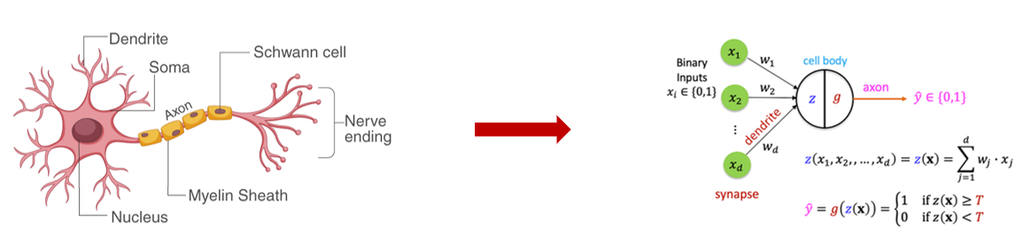

**Fonte:** Adaptado pelo autor (2026).

A primeira formalização matemática desses princípios resultou no *perceptron* (Rosenblatt 1958), também denominado rede neural de camada única, formulado como um classificador linear baseado na combinação ponderada das entradas e na aplicação de uma função de ativação. Embora esse modelo tenha desempenhado papel fundamental na consolidação das redes neurais artificiais como uma abordagem viável para problemas de aprendizagem supervisionada, sua formulação restringe a capacidade de representação a fronteiras de decisão *linearmente separáveis*. Essa limitação evidenciou a necessidade de arquiteturas mais expressivas, capazes de incorporar transformações não lineares sucessivas, motivando o desenvolvimento das *redes neurais multicamadas* (*multilayer perceptron*).

Na arquitetura *multilayer perceptron*, a introdução de uma ou mais camadas ocultas entre a camada de entrada e a camada de saída amplia substancialmente o poder de modelagem do sistema. Cada camada realiza combinações ponderadas das entradas e aplica funções de ativação, enquanto a informação é propagada sequencialmente da camada de entrada até a camada de saída. O ajuste dos pesos das conexões ocorre segundo uma *regra de aprendizado*, sendo o procedimento canônico o *método de retropropagação do erro*, no qual o erro é inicialmente calculado na camada de saída e, em seguida, propagado de forma reversa pelas camadas ocultas. Diferentes estratégias de otimização podem ser empregadas nesse contexto, incluindo o método dos mínimos quadrados médios, algoritmos baseados em descida do gradiente, a regra de Newton e o gradiente conjugado, entre outros, os quais determinam a dinâmica de convergência do processo de aprendizado (Haykin 2009; Du e Swamy 2013).

Além do *multilayer perceptron*, a literatura descreve diferentes arquiteturas de redes neurais artificiais, que se distinguem quanto à organização estrutural das camadas, ao fluxo da informação e aos mecanismos de transformação interna dos dados (Du e Swamy 2013). Nesse conjunto, incluem-se arquiteturas *feedforward* gerais, redes neurais convolucionais e redes neurais recorrentes, bem como extensões baseadas em mecanismos de memória, portas de controle e atenção, além de formulações híbridas. Em tarefas de classificação, são mais frequentemente empregadas redes *feedforward* multicamadas — entre elas o *multilayer perceptron* —, redes convolucionais e variantes recorrentes adaptadas a dados sequenciais. No âmbito deste texto, adota-se exclusivamente a rede do tipo *multilayer perceptron* descrita anteriormente como modelo de referência. Na sequência, são apresentados os elementos estruturais que compõem essa arquitetura.

**(I) Arquitetura *Multilayer Perceptron***

Considere uma rede neural do tipo *multilayer perceptron* composta por $L$ camadas, sendo uma camada de entrada, $L-2$ camadas ocultas e uma camada de saída. Cada camada $l$, para $l = 1, \ldots, L$, é constituída por $n_l$ neurônios artificiais. A entrada da rede é representada por um vetor $\mathbf{x} \in \mathbb{R}^{n_0}$, que contém as variáveis explicativas do problema, as quais são fornecidas diretamente à camada de entrada, definida como $\mathbf{a}^{(0)} = \mathbf{x}$. Do ponto de vista estrutural, o processamento da informação no *multilayer perceptron* ocorre por meio de uma propagação direta (*forward propagation*), na qual as ativações são transmitidas sequencialmente da camada de entrada até a camada de saída. Para cada camada $l$, calcula-se inicialmente um vetor linear $\mathbf{z}^{(l)}$, que representa o potencial de ativação dos neurônios dessa camada, obtido pela multiplicação da matriz de pesos $\mathbf{W}^{(l)} \in \mathbb{R}^{n_l \times n_{l-1}}$ pelo vetor de ativações da camada anterior $\mathbf{a}^{(l-1)}$, acrescida de um vetor de vieses $\mathbf{b}^{(l)} \in \mathbb{R}^{n_l}$, isto é,
$$\begin{align}\\
\mathbf{z}^{(l)} = \mathbf{W}^{(l)} \mathbf{a}^{(l-1)} + \mathbf{b}^{(l)}\\\\
\end{align}$$
em que cada elemento $w^{(l)}_{ij}$ da matriz $\mathbf{W}^{(l)}$ quantifica a contribuição da ativação $a^{(l-1)}_j$ para o neurônio $i$ da camada $l$, definindo a intensidade e o sentido dessa influência, enquanto o vetor de vieses $\mathbf{b}^{(l)}$ atua como um termo de ajuste individual para cada neurônio, independentemente da magnitude das entradas. O vetor $\mathbf{z}^{(l)}$ é então transformado pela aplicação, componente a componente, de uma *função de ativação* $\zeta^{(l)}(\cdot)$, resultando no vetor de ativações da camada $l$, dado por:
$$\begin{align}\\
\mathbf{a}^{(l)} = \zeta^{(l)}\!\left( \mathbf{z}^{(l)} \right)\\\\
\end{align}$$
A *função de ativação* atua como um mecanismo de transformação que rompe a linearidade da composição sucessiva das camadas, possibilitando ao *multilayer perceptron* modelar fronteiras de decisão de maior complexidade no espaço de atributos. Esse encadeamento de transformações lineares seguidas de funções não lineares repete-se ao longo das camadas ocultas da rede, conduzindo à construção progressiva de representações internas hierarquizadas. Ao final da propagação direta, a camada de saída produz o vetor de ativações $\mathbf{a}^{(L)}$, que corresponde à saída do modelo e cuja interpretação depende da função de ativação adotada na camada final. Dessa forma, o *multilayer perceptron* define uma função paramétrica da forma:
$$\begin{align}\\
f(\mathbf{x}; \Theta) = \mathbf{a}^{(L)}\\\\
\end{align}$$
em que o conjunto de parâmetros $\Theta = \{ \mathbf{W}^{(l)}, \mathbf{b}^{(l)} \}_{l=1}^{L}$ engloba todas as matrizes de pesos e vetores de vieses da arquitetura, os quais determinam como a informação é transformada e combinada ao longo das camadas da rede e são ajustados durante o processo de treinamento por meio da minimização de uma função de perda que quantifica o desvio entre as respostas observadas e as predições geradas pelo modelo.

**(II) Funções de Ativação**

- **Sigmoide:** É uma função de ativação utilizada para classificação binária. Sua principal característica é a capacidade de transformar os valores de entrada em um intervalo entre $0$ e $1$, o que a torna adequada para modelar probabilidades associadas a duas classes mutuamente exclusivas. Entretanto, um ponto negativo dessa função é o fenômeno conhecido como *desvanecimento do gradiente*, que ocorre para valores extremos da entrada — muito grandes ou muito pequenos —, fazendo com que a derivada da função tenda a zero, podendo comprometer a eficiência do aprendizado, ao dificultar a propagação do gradiente durante o processo de retropropagação. A formulação matemática dessa função é dada por:
  $$\begin{align}\\
  \sigma(t) = \frac{1}{1 + e^{-t}}\\\\
  \end{align}$$
  onde $t \in \mathbb{R}$ representa a entrada da função.
- **Tangente Hiperbólica:** É uma função de ativação utilizada, em geral, em arquiteturas profundas. Assim como a função sigmoide, ela apresenta um comportamento não linear e um gradiente suave, o que favorece a convergência dos algoritmos de treinamento baseados em gradiente. A principal diferença em relação à sigmoide é o intervalo de saída: enquanto a sigmoide mapeia os valores da entrada para o intervalo $(0, 1)$, a tangente hiperbólica transforma a entrada em valores no intervalo $(-1, 1)$, o que pode conferir vantagens numéricas no treinamento de redes profundas, por centralizar os dados em torno de zero. Matematicamente, a função tangente hiperbólica é definida por:
  $$\begin{align}\\
  \tanh(t) = \frac{e^{t} - e^{-t}}{e^{t} + e^{-t}}\\\\
  \end{align}$$
  onde $t \in \mathbb{R}$ representa a entrada da função.
- **Unidade Linear Retificada (ReLU):** É uma das funções de ativação mais utilizadas em redes neurais modernas. Sua popularidade se deve à simplicidade computacional e ao fato de mitigar, em muitos casos, o problema do desvanecimento do gradiente, comumente observado em funções de ativação como a sigmoide ou a tangente hiperbólica. Matematicamente, a ReLU é definida por:
  $$\begin{align}\\
  \mathrm{ReLU}(t) = \max(0, t)\\\\
  \end{align}$$
  onde $t \in \mathbb{R}$ representa a entrada da função. Com essa ativação, a saída do neurônio é igual à entrada se esta for positiva e zero caso contrário. No entanto, essa função não está isenta de limitações. Uma das principais desvantagens é a chamada *morte dos neurônios*: quando os valores de entrada de determinados neurônios são sempre negativos, suas saídas e gradientes permanecem nulos, o que impede a atualização dos pesos durante o treinamento.
- **Modificações da ReLU:** Diversas variantes da função ReLU foram propostas com o intuito de mitigar suas limitações, em especial o problema da morte dos neurônios. Entre as mais relevantes, destacam-se:
  - **Leaky ReLU:** Introduz uma pequena inclinação para valores negativos, em vez de zerar completamente. Isto é,
    $$\begin{align}\\
    f(t) = \begin{cases}
    t, & \text{se } t \geqslant 0 \\\\
    \alpha t, & \text{se } t < 0
    \end{cases}\\\\
    \end{align}$$
    em que $\alpha$ é um parâmetro fixo de pequeno valor (por exemplo, $0{,}01$). Essa modificação permite que neurônios com entradas negativas preservem gradientes não nulos, reduzindo a probabilidade de inatividade permanente.
  - **Parametric ReLU:** Generaliza a *Leaky ReLU* ao tornar $\alpha$ um parâmetro ajustável durante o treinamento, de forma que a própria rede aprenda a inclinação ótima para a região negativa.
  - **Randomized Leaky ReLU:** Nesse caso, $\alpha$ é amostrado aleatoriamente a partir de um intervalo pré-definido durante o treinamento e fixado na fase de inferência. Essa estratégia atua como forma de regularização estocástica, contribuindo para a redução de *overfitting*.
    $$\begin{align}\\
    f(t) = \begin{cases}
    t, & \text{se } t \geqslant 0 \\\\
    \alpha t, & \text{se } t < 0 \quad \alpha \sim \mathcal{U}(\alpha_{\min}, \alpha_{\max})
    \end{cases}\\\\
    \end{align}$$
  - **Exponential Linear Unit (ELU):** Para valores negativos, a função cresce exponencialmente em vez de ser linear ou nula, isto é,
    $$\begin{align}\\
    f(t) = \begin{cases}
    t, & \text{se } t \geqslant 0 \\\\
    \alpha (e^{t} - 1), & \text{se } t < 0
    \end{cases}\\\\
    \end{align}$$
- **Softmax:** É empregada em problemas de classificação multiclasse, sobretudo na camada de saída de redes neurais. Seu objetivo é converter um vetor de valores reais (*logits*) em uma distribuição de probabilidade cuja soma total é igual a $1$, o que permite interpretar cada saída como a probabilidade de pertencimento a uma classe. Seja $\mathbf{z} = (z_1, \ldots, z_K)$ o vetor de entradas da camada de saída de uma rede neural com $K$ neurônios, tem-se que:
  $$\begin{align}\\
  \mathrm{Softmax}(z_i) = \frac{e^{z_i}}{\sum_{j=1}^{K} e^{z_j}}\\\\
  \end{align}$$
  Cada elemento $z_i$ é transformado pela função exponencial, o que assegura valores positivos, e posteriormente normalizado pela soma das exponenciais de todos os $K$ componentes. Assim, a saída $y_i$ pertence ao intervalo $(0, 1)$ e satisfaz $\sum_{i=1}^{K} \mathrm{Softmax}(z_i) = 1$.

**(III) Etapas de Construção da Rede**

A construção de uma rede neural artificial do tipo *multilayer perceptron* (MLP) requer a definição de uma arquitetura *feedforward* totalmente conectada, a especificação das funções de ativação associadas a cada camada e a implementação do processo de treinamento dos parâmetros do modelo, usualmente baseado no método de retropropagação do erro (*backpropagation*), no qual os gradientes de uma função de perda são calculados e propagados no sentido inverso ao da passagem direta, permitindo a atualização iterativa dos parâmetros. Para fins ilustrativos, considera-se aqui uma rede MLP simples composta por uma camada de entrada, uma única camada oculta e uma camada de saída, nas quais cada neurônio de uma camada está conectado a todos os neurônios da camada subsequente, caracterizando a forma mais simples dessa arquitetura. Essa arquitetura é instanciada da seguinte forma:

- **Camada de Entrada (*Input Layer*):** composta por $n_x$ neurônios, onde $n_x$ corresponde ao número de variáveis preditoras consideradas no modelo (após eventuais transformações e codificações).
- **Camada Oculta (*Hidden Layer*):** formada por $n_h$ neurônios, em que $n_h$ é definido a priori e tratado como hiperparâmetro do modelo.
- **Camada de Saída (*Output Layer*):** contém um único neurônio $n_y = 1$, uma vez que o problema corresponde a uma tarefa de classificação binária.
- **Saída do Modelo (*Output*):** interpretada como a probabilidade de a observação pertencer à classe positiva, assumindo valores no intervalo $(0,1)$.
- **Regra de Decisão:** para converter a probabilidade estimada em predição binária, adota-se um limiar $\tau$ (no exemplo, $\tau = 0{,}5$).

Com o processo de propagação direta, a rede neural é capaz de produzir uma saída para cada observação de entrada. Entretanto, para que o modelo aprenda de forma adequada, é necessário introduzir um mecanismo de avaliação do erro e de ajuste dos parâmetros. Nesse contexto, a discrepância entre as probabilidades preditas e os valores observados é quantificada por meio da função de custo de entropia cruzada binária, definida como:
$$\begin{align} \\
\mathcal{J} = -\frac{1}{m} \sum_{i=1}^{m} \Big[y^{(i)} \log\!\left(\hat{y}^{(i)}\right) + \left(1 - y^{(i)}\right) \log\!\left(1 - \hat{y}^{(i)}\right) \Big]\\\\
\end{align}$$
em que $m$ denota o número de observações no conjunto de dados, $y^{(i)}$ representa o valor real da classe associada à $i$-ésima observação e $\hat{y}^{(i)}$ corresponde à probabilidade predita pela rede neural para essa observação. A etapa subsequente é, então, o *processo de retropropagação*, no qual são calculados os gradientes da função de custo em relação a cada peso e viés da rede. Esses gradientes permitem atualizar os parâmetros segundo o *método da descida do gradiente*, reduzindo progressivamente o valor da função de custo. O ciclo completo — propagação direta, cálculo do erro, retropropagação e atualização dos parâmetros — é repetido ao longo de várias épocas de treinamento. Ao final, espera-se que a rede neural aprenda um conjunto de pesos e vieses capaz de produzir predições precisas e com boa capacidade de generalização para dados não observados. O *processo de retropropagação* é descrito pelas etapas:

- **(1) Erro na Camada de Saída:** A primeira etapa consiste em calcular a diferença entre a saída predita, $\hat{y}^{(i)}$, e o valor verdadeiro, $y^{(i)}$, isto é,
  $$\begin{align}\\
  dZ^{[2](i)} = a^{[2](i)} - y^{(i)}\\\\
  \end{align}$$
- **(2) Gradiente na Camada de Saída:** A partir de $dZ^{[2](i)}$, calculam-se os gradientes da função de custo em relação aos pesos e aos vieses da camada de saída. Esses gradientes são dados por:
  $$\begin{align}\\
  dW^{[2]} &= dZ^{[2](i)} \, a^{[1](i)T} \\\\
  db^{[2]} &= dZ^{[2](i)}\\\\
  \end{align}$$
- **(3) Propagação do Erro → Camada Oculta:** O erro calculado na camada de saída é propagado para a camada oculta de acordo com os pesos associados à saída, resultando em:
  $$\begin{align}\\
  dA^{[1](i)} = W^{[2]T} dZ^{[2](i)}\\\\
  \end{align}$$
  Como a camada oculta utiliza a função tangente hiperbólica como ativação, aplica-se a sua derivada, por meio da regra da cadeia, para obter o erro linear correspondente à camada oculta. Assim, tem-se
  $$\begin{align}\\
  dZ^{[1](i)} = dA^{[1](i)} \odot \left[ 1 - \left(a^{[1](i)}\right)^2 \right]\\\\
  \end{align}$$
  em que $\odot$ denota o produto elemento a elemento (produto de Hadamard). O termo $1 - \left(a^{[1](i)}\right)^2$ corresponde à derivada da função tangente hiperbólica avaliada nas ativações da camada oculta.
- **(4) Gradiente na Camada Oculta:** Com base em $dZ^{[1](i)}$, calculam-se os gradientes da função de custo em relação aos pesos e aos vieses da camada oculta. Esses gradientes são dados por:
  $$\begin{align}\\
  dW^{[1]} &= dZ^{[1](i)} \, x^{(i)T} \\\\
  db^{[1]} &= dZ^{[1](i)}\\\\
  \end{align}$$
- **(5) Atualização dos Parâmetros:** A partir de uma taxa de aprendizado $\alpha$, os pesos e vieses são atualizados utilizando os gradientes previamente calculados, de acordo com as expressões:
  $$\begin{align}\\
  W^{[2]} &\leftarrow W^{[2]} - \alpha \, dW^{[2]}, & b^{[2]} &\leftarrow b^{[2]} - \alpha \, db^{[2]} \\\\
  W^{[1]} &\leftarrow W^{[1]} - \alpha \, dW^{[1]}, & b^{[1]} &\leftarrow b^{[1]} - \alpha \, db^{[1]}\\\\
  \end{align}$$

**(IV) Implementação Computacional**

Conforme discutido em (III), o treinamento de uma rede neural do tipo MLP baseia-se em uma sequência estruturada de operações matemáticas que inclui a propagação direta das entradas, o cálculo da função de custo, a retropropagação do erro e a atualização iterativa dos parâmetros por meio do método da descida do gradiente. Nos algoritmos apresentados anteriormente, esse fluxo computacional foi explicitado inicialmente por meio de pseudocódigo, seguido de sua implementação em R, como estratégia para tornar o procedimento algorítmico mais transparente. No caso das redes neurais, entretanto, a própria formulação matemática detalhada em (III) fornece uma descrição explícita do algoritmo de treinamento, tornando desnecessária a etapa intermediária de formalização via pseudocódigo. Assim, com o objetivo de preservar a transparência metodológica e assegurar a reprodutibilidade analítica, opta-se por traduzir diretamente essa estrutura matemática em uma implementação computacional em R, detalhando cada uma das operações envolvidas no ajuste do modelo. Cabe ainda destacar que os procedimentos descritos em (III) são gerais e podem ser estendidos a arquiteturas com múltiplas camadas ocultas; neste texto, contudo, a implementação apresentada tem caráter ilustrativo e se restringe à arquitetura considerada nessa etapa, composta por três camadas: entrada, oculta e saída.

Para dar início à etapa computacional, procede-se à implementação da rede neural proposta na linguagem R, em estrita conformidade com a arquitetura previamente especificada. A implementação será conduzida de forma explícita e modular, refletindo diretamente as etapas matemáticas descritas em (III). Em particular, serão consideradas a inicialização dos pesos e vieses, a propagação direta das observações ao longo das camadas da rede, o cálculo da função de custo por entropia cruzada binária, a retropropagação do erro para obtenção dos gradientes e a atualização iterativa dos parâmetros por meio do método da descida do gradiente ao longo de múltiplas épocas de treinamento. Essa abordagem permite acompanhar detalhadamente o comportamento do algoritmo, avaliar a influência dos hiperparâmetros adotados — como a taxa de aprendizado e o número de épocas — e estabelecer uma correspondência direta entre a formulação teórica do modelo e sua implementação computacional. Assim, as etapas que envolvem a implementação são:

**(1) Tamanho das Camadas:** Uma rede neural busca otimizar um conjunto de parâmetros com o objetivo de produzir saídas adequadas às observações de entrada. Esses parâmetros, correspondentes aos pesos e vieses da rede, são inicialmente definidos de forma aleatória. No entanto, as dimensões das matrizes de parâmetros dependem diretamente do número de neurônios em cada camada da rede. Assim, para a correta inicialização dos pesos e vieses, é necessário determinar previamente o tamanho de cada camada da rede neural. Denotam-se:

- $n_x$: número de neurônios na camada de entrada;
- $n_h$: número de neurônios na camada oculta;
- $n_y$: número de neurônios na camada de saída.

A função `getLayerSize`, apresentada no Código 4.10, permite calcular e retornar o tamanho de cada camada a partir do conjunto de dados de entrada e do número de neurônios especificado para a camada oculta.

**Código 4.10.** Implementação da função `getLayerSize`.

```r
# ------------------------- Função `getLayerSize` ------------------------- #

getLayerSize      <- function(X, y, hidden_neurons, train = TRUE)
{
  n_x             <- dim(X)[1]
  n_h             <- hidden_neurons
  n_y             <- dim(y)[1]
  size            <- list("n_x" = n_x, "n_h" = n_h, "n_y" = n_y)
  return(size)
}
```

**(2) Inicialização dos Parâmetros:** Antes do início do treinamento da rede neural, é necessário inicializar os parâmetros treináveis, os quais correspondem aos pesos e aos vieses associados a cada camada. Para esse propósito, adota-se uma distribuição uniforme, de modo que os pesos assumam valores iniciais de pequena magnitude, favorecendo a estabilidade numérica e a convergência do algoritmo durante o processo de treinamento. Considerando a arquitetura da rede neural composta por três camadas — camada de entrada, camada oculta e camada de saída —, têm-se dois conjuntos de parâmetros a serem estimados:

- **1º conjunto:** $W_1$ e $b_1$, correspondentes à conexão entre a camada de entrada e a camada oculta;
- **2º conjunto:** $W_2$ e $b_2$, correspondentes à conexão entre a camada oculta e a camada de saída.

A função `initializeParameters`, apresentada no Código 4.11, permite inicializar os pesos e vieses da rede neural a partir do conjunto de dados de entrada e dos tamanhos de cada camada previamente definidos.

**Código 4.11.** Implementação da função `initializeParameters`.

```r
# ------------------------- Função `initializeParameters` ------------------------- #

initializeParameters      <- function(X, list_layer_size)
{
  m                           <- dim(data.matrix(X))[2]
  n_x                       <- list_layer_size$n_x
  n_h                       <- list_layer_size$n_h
  n_y                       <- list_layer_size$n_y
  W1                          <- matrix(runif(n_h*n_x), nrow = n_h, ncol = n_x, byrow = TRUE) * 0.01
  b1                          <- matrix(rep(0, n_h), nrow = n_h)
  W2                          <- matrix(runif(n_y*n_h), nrow = n_y, ncol = n_h, byrow = TRUE) * 0.01
  b2                          <- matrix(rep(0, n_y), nrow = n_y)
  params                      <- list("W1" = W1, "b1" = b1, "W2" = W2, "b2" = b2)
  return(params)
}
```

**(3) Definição das Funções de Ativação:** Para a camada de saída, utiliza-se a função sigmoide (Código 4.12), a qual é amplamente empregada em tarefas de classificação binária, uma vez que sua saída assume valores no intervalo $(0,1)$ e pode ser interpretada como a probabilidade de a observação pertencer à classe positiva. Para a camada oculta, adota-se a função tangente hiperbólica (`tanh`), disponível nativamente na linguagem **R**. Essa função transforma valores reais em um intervalo entre $-1$ e $1$, favorecendo a modelagem de relações não lineares e permitindo que os neurônios da camada oculta capturem padrões mais complexos presentes nos dados de entrada.

**Código 4.12.** Implementação da função `sigmoid`.

```r
# ------------------------- Função `sigmoid` ------------------------- #

sigmoid         <- function(x)
{
  return(1 / (1 + exp(-x)))
}
```

**(4) Propagação Direta (*Forward Propagation*):** A etapa seguinte consiste na definição do processo de propagação direta da rede neural. Para esse fim, a função `forwardPropagation` (Código 4.13) recebe como argumentos:

- `X`, que corresponde à matriz de entrada contendo os dados de treinamento;
- `params`, que representa a lista de parâmetros da rede, incluindo pesos e vieses;
- `layer_sizes`, que indica os tamanhos das camadas da rede neural.

A partir desses argumentos, são extraídos os tamanhos das camadas, bem como os pesos e vieses previamente inicializados, procedendo-se às operações de multiplicação matricial necessárias ao cálculo das ativações em cada camada. Essas operações são realizadas por meio do operador `%*%`.

**Código 4.13.** Implementação da função `forwardPropagation`.

```r
# ------------------------- Função `forwardPropagation` ------------------------- #

forwardPropagation    <- function(X, params, list_layer_size)
{
  n_h                     <- list_layer_size$n_h
  n_y                     <- list_layer_size$n_y
  b1_new                  <- matrix(rep(params$b1, dim(X)[2]), nrow = n_h)
  b2_new                  <- matrix(rep(params$b2, dim(X)[2]), nrow = n_y)
  Z1                        <- params$W1 %*% X + b1_new
  A1                        <- tanh(Z1)
  Z2                        <- params$W2 %*% A1 + b2_new
  A2                        <- sigmoid(Z2)
  cache                     <- list("Z1" = Z1, "A1" = A1, "Z2" = Z2, "A2" = A2)
  return(cache)
}
```

**(5) Cálculo da Função Custo:** Para o treinamento da rede neural, utiliza-se a função de perda binária, também conhecida como *entropia cruzada*, a qual é apropriada para problemas de classificação binária. Nesse contexto, dadas as predições $\hat{y}_i$ e os rótulos verdadeiros $y_i$, para um conjunto de $N$ observações, a função custo é definida por:
$$\begin{align}\\
\mathcal{J} = -\frac{1}{N} \sum_{i=1}^{N} \Big[y_i \log\!\left(\hat{y}_i\right) + \left(1 - y_i\right) \log\!\left(1 - \hat{y}_i\right) \Big]\tag{3.144}\\\\
\end{align}$$
A função `computeCost`, apresentada no Código 4.14, recebe como argumentos a matriz de entradas e o vetor de rótulos associados, retornando o valor médio da perda calculada sobre todas as observações do conjunto de dados.

```r
# ------------------------- Função `computeCost` ------------------------- #

computeCost             <- function(X, y, cache){
  m                       <- dim(X)[2]
  A2                      <- cache$A2
  logprobs            <- (log(A2) * y) + (log(1 - A2) * (1 - y))
  cost                  <- -sum(logprobs/m)
  return(cost)
}
```

**(6) Retropropagação (*Backward Propagation*):** A etapa seguinte consiste na definição do processo de retropropagação, o qual é responsável por calcular os gradientes dos pesos e vieses da rede neural a partir do erro entre as predições do modelo e os valores reais observados. Para esse propósito, a função `backwardPropagation` (Código 4.15) recebe como argumentos:

- `X`, correspondente à matriz de entrada dos dados de treinamento;
- `y`, que representa o vetor de rótulos verdadeiros associados aos dados de treinamento;
- `cache`, que armazena as ativações intermediárias calculadas durante a propagação direta (em particular, `A1` e `A2`);
- `params`, que contém a lista de parâmetros da rede neural;
- `layer_sizes`, que indica os tamanhos das camadas da rede.

**Código 4.15.** Implementação da função `backwardPropagation`.

```r
# ------------------------- Função `backwardPropagation` ------------------------- #

backwardPropagation       <- function(X, y, cache, params, list_layer_size)
{
  dZ2                       <- cache$A2 - y
  dW2                       <- 1/dim(X)[2] * (dZ2 %*% t(cache$A1))
  db2                       <- matrix(1/dim(X)[2] * sum(dZ2), nrow = list_layer_size$n_y)
  db2_new                 <- matrix(rep(db2, dim(X)[2]), nrow = list_layer_size$n_y)
  dZ1                       <- (t(params$W2) %*% dZ2) * (1 - cache$A1^2)
  dW1                       <- 1/dim(X)[2] * (dZ1 %*% t(X))
  db1                       <- matrix(1/dim(X)[2] * sum(dZ1), nrow = list_layer_size$n_h)
  db1_new                 <- matrix(rep(db1, dim(X)[2]), nrow = list_layer_size$n_h)
  grads                       <- list("dW1" = dW1, "db1" = db1, "dW2" = dW2, "db2" = db2)
  return(grads)
}
```

**(7) Atualização dos Parâmetros:** Após o cálculo dos gradientes obtidos na etapa de retropropagação, procede-se à atualização dos pesos e vieses da rede neural. Esse procedimento é realizado pela função `updateParameters` (Código 4.16), a qual recebe como argumentos:

- `grads`, que corresponde aos gradientes calculados durante a retropropagação;
- `params`, que representa os parâmetros atuais da rede neural;
- `learning_rate`, que indica a taxa de aprendizado.

A taxa de aprendizado, denotada por $\alpha$, é um hiperparâmetro fundamental, pois controla a magnitude das atualizações aplicadas aos pesos e vieses a cada iteração do algoritmo. Valores excessivamente elevados de $\alpha$ podem resultar em atualizações instáveis, fazendo com que o algoritmo ultrapasse o mínimo da função de custo e prejudique o processo de aprendizado do modelo.

**Código 4.16.** Implementação da função `updateParameters`.

```r
# ------------------------- Função `updateParameters` ------------------------- #

updateParameters    <- function(grads, params, learning_rate)
{
  W1                    <- params$W1 - learning_rate * grads$dW1
  b1                    <- params$b1 - learning_rate * grads$db1
  W2                    <- params$W2 - learning_rate * grads$dW2
  b2                    <- params$b2 - learning_rate * grads$db2
  updated_params    <- list("W1" = W1, "b1" = b1, "W2" = W2, "b2" = b2)
  return(updated_params)
}
```

**(8) Treinamento da Rede:** Com todos os componentes da rede devidamente definidos — inicialização dos parâmetros, funções de ativação, propagação direta, cálculo da função de custo, retropropagação e atualização dos pesos — torna-se possível implementar a função responsável pelo treinamento completo do modelo. A função `trainModel` (Código 4.17) conduz o ciclo de aprendizado da rede neural, aplicando iterativamente as etapas descritas anteriormente, de acordo com o seguinte fluxo:

- **(8.1)** Realiza a obtenção dos tamanhos das camadas por meio da função `getLayerSize` e procede à inicialização aleatória dos parâmetros utilizando a função `initializeParameters`;
- **(8.2)** Cria o vetor `cost_history`, destinado ao armazenamento dos valores da função de custo calculados a cada época, permitindo o acompanhamento da evolução do processo de treinamento;
- **(8.3)** Executa um laço de repetição (`for`) no qual, a cada iteração: (a) realiza a propagação direta, (b) calcula o valor da função de custo, (c) executa a retropropagação para obtenção dos gradientes, (d) atualiza os parâmetros da rede com base nos gradientes calculados e (e) substitui os parâmetros atuais pelos parâmetros atualizados.

**Código 4.17.** Implementação da função `trainModel`.

```r
# ------------------------- Função `trainModel` ------------------------- #

trainModel            <- function(X, y, num_iteration, hidden_neurons, lr)
{
  layer_size            <- getLayerSize(X, y, hidden_neurons)
  init_params         <- initializeParameters(X, layer_size)
  cost_history        <- c()

  for(i in 1:num_iteration)
  {
      fwd_prop        <- forwardPropagation(X, init_params, layer_size)
      cost            <- computeCost(X, y, fwd_prop)
      back_prop         <- backwardPropagation(X, y, fwd_prop, init_params, layer_size)
      update_params <- updateParameters(back_prop, init_params, learning_rate = lr)
      init_params   <- update_params
      cost_history  <- c(cost_history, cost)

      if(i %% 10000 == 0) cat("Iteration", i, " | Cost: ", cost, "\n")
    }
    model_out         <- list("updated_params" = update_params, "cost_hist" = cost_history)
    return(model_out)
}
```

**(9) Teste da Rede:** Como etapa final da implementação da rede neural proposta, procede-se à fase de teste do modelo, na qual são realizadas predições a partir dos parâmetros estimados durante o treinamento. Para esse fim, são executados os seguintes passos:

- **(9.1)** Obtenção dos tamanhos das camadas da rede no conjunto de teste, utilizando a função `getLayerSize`;
- **(9.2)** Execução do processo de propagação direta empregando os parâmetros previamente treinados;
- **(9.3)** Retorno da predição final (função `makePrediction`, apresentada no Código 4.18) da rede neural para cada observação do conjunto de teste.

**Código 4.18.** Implementação da função `makePrediction`.

```r
# ------------------------- Função `makePrediction` ------------------------- #

makePrediction      <- function(X, y, train_model, hidden_neurons)
{
  layer_size          <- getLayerSize(X, y, hidden_neurons)
  params              <- train_model$updated_params
  fwd_prop          <- forwardPropagation(X, params, layer_size)
  pred                <- fwd_prop$A2
  pred                <- ifelse(pred >= 0.5, 1, 0)
  return(pred)
}
```

Atividade Prática 4.23

Considere o conjunto de dados `SAheart`, disponibilizado na biblioteca `ElemStatLearn`, que reúne informações clínicas e laboratoriais de indivíduos participantes de um estudo sobre *doença cardíaca coronariana* na África do Sul. Nesse conjunto, a variável resposta `chd` indica a presença (`1`) ou ausência (`0`) de doença coronariana, enquanto as variáveis explicativas incluem fatores de risco cardiovasculares contínuos e categóricos, tais como pressão arterial sistólica (`sbp`), consumo de tabaco (`tobacco`), colesterol LDL (`ldl`), adiposidade (`adiposity`), histórico familiar de doença coronariana (`famhist`), escore de comportamento tipo A (`typea`), obesidade (`obesity`), consumo de álcool (`alcohol`) e idade (`age`). Nesta atividade, considere a *rede neural MLP (Multilayer Perceptron)* implementada anteriormente com o objetivo de avaliar seu desempenho na atribuição dos rótulos associados à presença ou ausência de doença coronariana. A prática deve ser conduzida de acordo com as seguintes instruções:

- Particionar a base de dados segundo o método *hold-out*, destinando $70\%$ das observações ao conjunto de treinamento e $30\%$ ao conjunto de teste;
- Realizar o pré-processamento das variáveis preditoras, contemplando:
  - a codificação de variáveis categóricas, em particular `famhist`, por meio de *one-hot encoding* (por exemplo, via `model.matrix`);
  - a padronização de todas as variáveis explicativas resultantes, utilizando média e desvio padrão estimados *exclusivamente no conjunto de treinamento*, evitando vazamento de informação;
- Construir a arquitetura da rede neural MLP composta por:
  - uma *camada de entrada* com $n_x$ neurônios, correspondente ao número total de variáveis preditoras após a codificação;
  - uma *camada oculta* com $n_h = 20$ neurônios, utilizando a função de ativação `tanh`;
  - uma *camada de saída* com $n_y = 1$ neurônio, empregando a função sigmoide, de modo que a saída $\hat{y}$ represente a probabilidade predita de ocorrência de doença coronariana;
- Treinar a rede ao longo de um número fixo de épocas (por exemplo, 500 épocas), executando, a cada iteração:
  - a propagação direta (*forward propagation*);
  - o cálculo da função de custo baseada na *entropia cruzada binária*;
  - a retropropagação do erro (*backpropagation*);
  - a atualização dos parâmetros por descida do gradiente, controlada por uma taxa de aprendizado $\alpha$;
- Obter, ao final do treinamento, as probabilidades preditas $\hat{y}$ e os rótulos preditos no conjunto de teste, adotando um limiar de decisão $\tau$ (por exemplo, $\tau = 0.5$) para a conversão de probabilidades em classes. Por fim, avaliar o desempenho preditivo da rede neural com base nas medidas de avaliação para classificação discutidas na Seção 4.4.

**(V) Bibliotecas do R**

Como alternativa à implementação computacional direta das *redes neurais artificiais do tipo MLP*, o ambiente R disponibiliza bibliotecas consolidadas que diferem quanto ao nível de abstração, ao grau de controle sobre a arquitetura da rede e à integração com procedimentos de validação preditiva. Dentre elas, destaca-se a biblioteca `nnet` (Venables e Ripley 2002), que oferece uma implementação clássica e relativamente transparente de MLPs com uma ou poucas camadas ocultas, permitindo ao analista especificar a topologia da rede, a função de ativação implícita, parâmetros de treinamento e mecanismos básicos de regularização, com custo computacional moderado. Por outro lado, em um nível mais elevado de abstração, a biblioteca `keras` (Allaire e Chollet 2024) possibilita a especificação e o treinamento de redes neurais simples ou profundas por meio de uma interface de alto nível, com amplo suporte a arquiteturas complexas, estratégias avançadas de otimização e regularização, além de integração nativa com *backends* de alto desempenho. Essa flexibilidade, contudo, vem acompanhada de menor transparência dos mecanismos internos de aprendizagem e de maior complexidade conceitual e computacional. De forma geral, tais bibliotecas reduzem a necessidade de codificação manual e permitem que a análise se concentre na definição da arquitetura, na escolha de hiperparâmetros e na avaliação preditiva. No entanto, impõem diferentes limitações quanto ao controle fino do processo de otimização, à interpretabilidade dos pesos sinápticos e à clareza do procedimento de treinamento. Neste texto, a discussão restringe-se a abordagens compatíveis com o escopo estatístico clássico, de modo que a biblioteca `keras`, embora relevante, é considerada fora do escopo deste texto.

**Biblioteca `nnet`**

A biblioteca `nnet` (Venables e Ripley 2002) permitindo o ajuste direto da arquitetura e da regularização do modelo por meio da definição explícita de hiperparâmetros, como o número de unidades na camada intermediária e o parâmetro de penalização aplicado aos pesos. O pré-processamento das covariáveis — incluindo, quando apropriado, centralização e escalonamento — é conduzido externamente ao modelo, assim como a definição do esquema de particionamento amostral para treinamento e avaliação. O processo de estimação é controlado por parâmetros que regulam o treinamento iterativo, a exemplo do número máximo de iterações e da exibição do traço de convergência, favorecendo rigor metodológico, transparência do ajuste e reprodutibilidade em estudos de natureza preditiva.

- **Função**: `nnet()`
- **Argumentos**:
  - `x` / `y`: matriz de preditores (`x`) e vetor resposta (`y`), ou `formula` quando se utiliza o método de fórmula.
  - `size`: número de unidades (neurônios) na camada oculta.
  - `decay`: penalização (*weight decay*) aplicada aos pesos como regularização.
  - `maxit`: número máximo de iterações do algoritmo de treinamento.
  - `entropy`: uso da função de perda de entropia cruzada para classificação.
  - `trace`: exibição do progresso do treinamento.

Atividade Prática 4.24

Para a aplicação de *redes neurais artificiais do tipo MLP* em um contexto de *classificação binária* utilizando a biblioteca `nnet`, considere o conjunto de dados `SAheart`, disponibilizado na biblioteca `ElemStatLearn`. Para estes dados, assuma como variável resposta a presença de doença cardíaca coronariana, representada por `chd` (classes $0$ e $1$), e como variáveis explicativas os fatores de risco `sbp` (pressão arterial sistólica), `tobacco` (consumo cumulativo de tabaco), `ldl` (colesterol LDL), `adiposity` (adiposidade), `famhist` (histórico familiar de doença coronariana), `typea` (escore de comportamento tipo A), `obesity` (obesidade), `alcohol` (consumo de álcool) e `age` (idade). A prática deve ser conduzida de acordo com as seguintes instruções:

- Realizar o pré-processamento dos dados, contemplando:
  - a codificação adequada de `chd` como fator binário;
  - a codificação de variáveis categóricas, em particular `famhist`, por meio de *one-hot encoding* quando necessário;
  - a padronização das variáveis explicativas;
- Particionar o conjunto de dados em conjuntos de treinamento e teste, por exemplo, nas proporções de $70\%$ e $30\%$, garantindo a preservação das proporções das classes;
- Ajustar um classificador MLP por meio da função `nnet()` (biblioteca `nnet`);
- Investigar diferentes configurações do modelo, variando:
  - o número de neurônios na camada oculta `size` (por exemplo, `size` $\in \{3, 5, 10, 20\}$);
  - o parâmetro de regularização por decaimento de pesos `decay` (por exemplo, `decay` $\in \{0, 10^{-4}, 10^{-3}, 10^{-2}\}$);
  - o número máximo de iterações `maxit` (por exemplo, `maxit` $\in \{200, 500, 1000\}$);
- Obter as probabilidades preditas para a classe `chd = 1` no conjunto de teste e convertê-las em rótulos de classe por meio de um limiar de decisão $\tau$ (por exemplo, $\tau = 0.5$), explorando valores alternativos de $\tau$ quando pertinente;
- Por fim, avaliar o desempenho preditivo do classificador com base nas medidas de avaliação para classificação discutidas na Seção 4.4.

## Referências Bibliográficas

Allaire, JJ, e François Chollet. 2024. *keras: R Interface to ’Keras’*. https://CRAN.R-project.org/package=keras.

Alpaydin, Ethem. 2021. *Machine Learning*. MIT Press.

Beygelzimer, Alina, Sham Kakadet, John Langford, Sunil Arya, David Mount, e Shengqiao Li. 2024. *FNN: Fast Nearest Neighbor Search Algorithms and Applications*. Cambridge University Press.

Bishop, Christopher M., e Nasser M. Nasrabadi. 2006. *Pattern Recognition and Machine Learning*. Springer.

Box, George E. P., e George C. Tiao. 2011. *Bayesian Inference in Statistical Analysis*. Hoboken, NJ: John Wiley & Sons.

Breiman, Leo. 2001. «Random Forests». *Machine learning* 45 (1): 5–32.

Breiman, Leo, Jerome H. Friedman, Richard A. Olshen, e Charles J. Stone. 1984. *Classification and Regression Trees*. Belmont, CA: Wadsworth International Group.

———. 2017. *Classification and Regression Trees*. 2.ª ed. Boca Raton, FL: Chapman; Hall/CRC.

Chen, Tianqi, e Carlos Guestrin. 2016. «XGBoost: A Scalable Tree Boosting System». Em *Proceedings of the 22nd ACM SIGKDD International Conference on Knowledge Discovery and Data Mining (KDD ’16)*, 785–94. ACM. https://doi.org/10.1145/2939672.2939785.

Cortes, Corinna, e Vladimir Vapnik. 1995. «Support-vector networks». *Machine learning* 20: 273–97.

Du, Ke-Lin, e Madisetti N. S. Swamy. 2013. *Neural Networks and Statistical Learning*. Springer Science & Business Media.

Fernández, Alberto, Salvador Garcı́a, Mikel Galar, Ronaldo C Prati, Bartosz Krawczyk, e Francisco Herrera. 2018. *Learning from imbalanced data sets*. Vol. 10. 2018. Springer.

Fisher, Aaron, Cynthia Rudin, e Francesca Dominici. 2019. «All Models Are Wrong, but Many Are Useful: Learning a Variable’s Importance by Studying an Entire Class of Prediction Models Simultaneously». *Journal of Machine Learning Research* 20 (177): 1–81.

Fisher, Ronald A. 1936. «The Use of Multiple Measurements in Taxonomic Problems». *Annals of Eugenics* 7 (2): 179–88.

Friedman, Jerome H. 2001. «Greedy Function Approximation: A Gradient Boosting Machine». *Annals of Statistics* 29 (5): 1189–1232.

Friedman, Jerome, Trevor Hastie, e Rob Tibshirani. 2010. «Regularization Paths for Generalized Linear Models via Coordinate Descent». *Journal of Statistical Software* 33 (1): 1–22. https://doi.org/10.18637/jss.v033.i01.

Geeks for Geeks. 2025. «Supervised and Unsupervised learning». GeeksforGeeks. 2025. https://www.geeksforgeeks.org/machine-learning/supervised-unsupervised-learning/.

Gelman, Andrew, John B. Carlin, Hal S. Stern, e Donald B. Rubin. 1995. *Bayesian Data Analysis*. Chapman; Hall/CRC.

Greenwell, Brandon M. 2022. *Tree-Based Methods for Statistical Learning in R*. Boca Raton, FL, USA: Chapman & Hall/CRC.

Hastie, Trevor, Robert Tibshirani, e Jerome Friedman. 2009. *The Elements of Statistical Learning*. Springer Series em Statistics. New York: Springer.

Haykin, Simon. 2009. *Neural Networks and Learning Machines*. 3.ª ed. Upper Saddle River, NJ: Prentice Hall.

Hosmer, David W., e Stanley Lemeshow. 2000. *Applied Logistic Regression*. 2.ª ed. New York, NY, USA: Wiley.

Karatzoglou, Alexandros, Alex J. Smola, Kurt Hornik, e Achim Zeileis. 2004. «kernlab – An S4 Package for Kernel Methods in R». *Journal of Statistical Software* 11 (9): 1–20. https://doi.org/10.18637/jss.v011.i09.

Kim, Sang-Bum, Hee-Cheol Seo, e Hae Chang Rim. 2003. «Poisson naive bayes for text classification with feature weighting». Em *Proceedings of the sixth international workshop on Information retrieval with Asian languages*, 33–40.

Kramer, Oliver. 2013. «K-Nearest Neighbors». Em *Dimensionality Reduction with Unsupervised Nearest Neighbors*, 13–23. Springer.

Kuhn, Max. 2008. «Building Predictive Models in R Using the caret Package». *Journal of Statistical Software* 28 (5): 1–26. https://doi.org/10.18637/jss.v028.i05.

Kuhn, Max, e Kjell Johnson. 2013. *Applied Predictive Modeling*. New York: Springer.

Lantz, Brett. 2019. *Machine Learning with R: Expert Techniques for Predictive Modeling*. Packt Publishing.

Liaw, Andy, e Matthew Wiener. 2002. «Classification and Regression by randomForest». *R News* 2 (3): 18–22. https://CRAN.R-project.org/doc/Rnews/.

Majka, Michal. 2024. *naivebayes: High Performance Implementation of the Naive Bayes Algorithm in R*. https://CRAN.R-project.org/package=naivebayes.

Mercer, J. 1909. «Functions of Positive and Negative Type, and their Connection with the Theory of Integral Equations». *Philosophical Transactions of the Royal Society of London. Series A* 209: 415–46. https://doi.org/10.1098/rsta.1909.0016.

Meyer, David, Evgenia Dimitriadou, Kurt Hornik, Andreas Weingessel, e Friedrich Leisch. 2019. *e1071: Misc Functions of the Department of Statistics, Probability Theory Group (Formerly: E1071), TU Wien*. https://CRAN.R-project.org/package=e1071.

Mitchell, Tom M. 1983. *Machine Learning*. New York: McGraw-Hill.

Quinlan, J. R. 1986. «Induction of decision trees». *Machine Learning* 1 (1): 81–106. https://doi.org/10.1007/BF00116251.

Quinlan, J. Ross. 1993. *C4.5: Programs for Machine Learning*. San Mateo, CA, USA: Morgan Kaufmann.

Reddy, Eguturi Manjith Kumar, Akash Gurrala, Vasireddy Bindu Hasitha, e Korupalli V Rajesh Kumar. 2022. «Introduction to Naive Bayes and a review on its subtypes with applications». *Bayesian reasoning and gaussian processes for machine learning applications*, 1–14.

Ridgeway, Greg, e GBM Developers. 2026. *gbm: Generalized Boosted Regression Models*. https://CRAN.R-project.org/package=gbm.

Rosenblatt, Frank. 1958. «The Perceptron: A Probabilistic Model for Information Storage and Organization in the Brain». *Psychological Review* 65 (6): 386–408. https://doi.org/10.1037/h0042519.

Schapiro, A., e Nicholas B. Turk-Browne. 2015. «Statistical Learning». *Brain Mapping* 3 (1): 501–6.

Schliep, Klaus, e Klaus Hechenbichler. 2016. *kknn: Weighted k-Nearest Neighbors*.

Shalev-Shwartz, Shai, e Shai Ben-David. 2014. *Understanding Machine Learning: From Theory to Algorithms*. Cambridge, UK: Cambridge University Press.

Therneau, Terry, e Beth Atkinson. 2025. *rpart: Recursive Partitioning and Regression Trees*. https://CRAN.R-project.org/package=rpart.

Tibshirani, Robert. 1996. «Regression Shrinkage and Selection via the Lasso». *Journal of the Royal Statistical Society: Series B* 58 (1): 267–88.

Vapnik, Vladimir N. 1998. *Statistical Learning Theory*. New York, NY, USA: Wiley.

Venables, W. N., e B. D. Ripley. 2002. *Modern Applied Statistics with S*. Fourth. New York: Springer. https://www.stats.ox.ac.uk/pub/MASS4/.

Wang, H., ZeZXeZBePJ Lei, X. Zhang, B. Zhou, e J. Peng. 2016. «Machine Learning Basics». *Deep Learning*, 98–164.

Witten, Ian H., Eibe Frank, Mark A. Hall, e Christopher J. Pal. 2017. *Data Mining: Practical Machine Learning Tools and Techniques*. 4.ª ed. Boston: Morgan Kaufmann.

Zhou, Zhi-Hua. 2021. *Machine Learning*. Springer Nature.

Zou, Hui, e Trevor Hastie. 2005. «Regularization and Variable Selection via the Elastic Net». *Journal of the Royal Statistical Society: Series B* 67 (2): 301–20.